# Introduction to Deep Learning

Classification – Binary, no validation

Rick Scavetta

# Session 1

## Functions & Take-home Message

### Take-home Message

In this case study, we’ll perform a binary classification to predict one of two possible outcomes from 13 predictor variables.

We’ll use the following functions in our network:

| Name | Function |
| --- | --- |
| Loss function | `binary_crossentropy` |
| Metric | `accuracy` |
| last-layer activation function | `sigmoid` |

## Part 1: Data Preparation

### Obtain data

We already saw how to obtain and transform the data, so I’m just going to call those functions here. For a classification, it would make more sense to name our `_targets` as `_labels` instead. But we’ll just use the same names as before.

```r
source("Boston_Z.R")
```

### Prepare the training data:

The target, i.e. response, variable is continuous, but for this example, we’ll pretend that it’s binary so that we can see how to handle a binary classification.

```r
str(train_targets)
```

```
##  num [1:404(1d)] 15.2 42.3 50 21.1 17.7 18.5 11.3 15.6 15.6 14.4 ...
```

```r
str(test_targets)
```

```
##  num [1:102(1d)] 7.2 18.8 19 27 22.2 24.5 31.2 22.9 20.5 23.2 ...
```

```r
train_targets <- as.numeric(cut(train_targets, seq(0,50,25))) - 1
table(train_targets)
```

```
## train_targets
##   0   1
## 310  94
```

```r
test_targets <- as.numeric(cut(test_targets, seq(0,50,25))) - 1
table(test_targets)
```

```
## test_targets
##  0  1
## 72 30
```

## Part 2: Define Network

### Define the network

Here we specify the final activation function. We’re going to use the sigmoid activation function, which will return a single value. That matches the format of our labels.

```r
network <- keras_model_sequential() %>%
  layer_dense(units = 2^6, activation = "relu", input_shape = c(13)) %>%
  layer_dense(units = 2^6, activation = "relu") %>%
  layer_dense(units = 1, activation = "sigmoid")
```

### View a summary of the network

```r
summary(network)
```

```
## ___________________________________________________________________________
## Layer (type)                     Output Shape                  Param #
## ===========================================================================
## dense_1 (Dense)                  (None, 64)                    896
## ___________________________________________________________________________
## dense_2 (Dense)                  (None, 64)                    4160
## ___________________________________________________________________________
## dense_3 (Dense)                  (None, 1)                     65
## ===========================================================================
## Total params: 5,121
## Trainable params: 5,121
## Non-trainable params: 0
## ___________________________________________________________________________
```

### Compile

Instead of `categorical_crossentropy` we’re going to use `binary_crossentropy` since we only have two possible classes.

```r
network %>% compile(
  optimizer = "rmsprop",
  loss = "binary_crossentropy",
  metrics = "accuracy"
)
```

## Part 3: Training our approach

```r
history <- network %>% fit(
  train_data,
  train_targets,
  epochs = 100,
  batch_size = 2^4
  )
```

Let’s display its loss and accuracy curves:

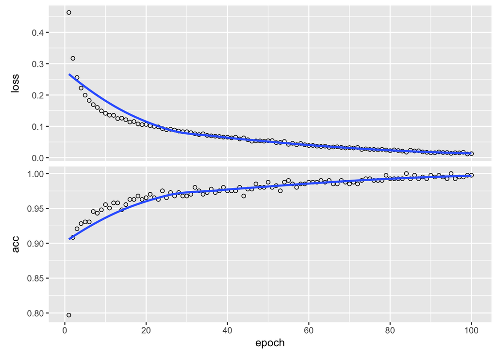

```r
plot(history)
```

```r
network <- keras_model_sequential() %>%
  layer_dense(units = 2^6, activation = "relu", input_shape = c(13)) %>%
  layer_dense(units = 2^6, activation = "relu") %>%
  layer_dense(units = 1, activation = "sigmoid")

network %>% compile(
  optimizer = "rmsprop",
  loss = "binary_crossentropy",
  metrics = "accuracy"
)

history <- network %>% fit(
  train_data,
  train_targets,
  epochs = 40,
  batch_size = 2^4)
```

## Part 4: Check output

### Metrics

```r
metrics <- network %>% evaluate(test_data, test_targets)
```

```r
metrics
```

```
## $loss
## [1] 0.5282202
##
## $acc
## [1] 0.9117647
```

The error rate, i.e. proportion of incorrect calling, is 0.0882353.

### Predictions

```r
network %>% predict_classes(test_data[1:10,])
```

```
##       [,1]
##  [1,]    0
##  [2,]    0
##  [3,]    0
##  [4,]    1
##  [5,]    0
##  [6,]    0
##  [7,]    1
##  [8,]    0
##  [9,]    0
## [10,]    0
```

```r
predictions <- network %>% predict_classes(test_data)
actual <- unlist(test_targets)
totalmisses <- sum(predictions != actual)
totalmisses
```

```
## [1] 9
```

A total of 9 mismatches occured.

### Confusion Matrix

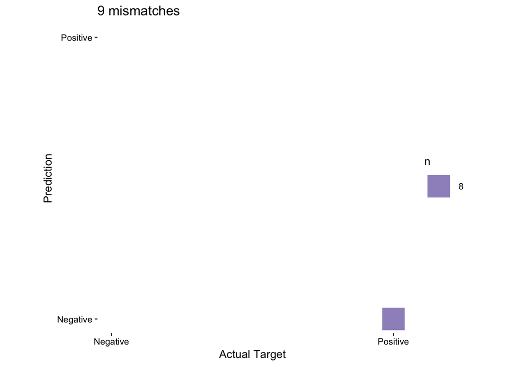